# Making Money by Being Wrong

Stock Trading From Social Media Sentiment Analysis

Art Steinmetz

## Goals

- Learn how to manage large datasets with R and duckplyr.
- Learn how to potentially profit from social media posters being reliably wrong.

## Who I Am

- Retired Investment Professional (Global Macro Fixed Income)
- Fund Board Member at BlackRock
- Consultant for Posit
- Data Science Hobbyist

## I Write About Data Science at [outsiderdata.net](https://outsiderdata.netlify.app/)

[figure not shown]

## Background

- Picking stocks that will go up is hard.
- Picking stocks that will go down also is hard.
- Being skilled at either could make you a lot of money.
- **But what if we could find people who are reliably wrong?**

## Social Media Sentiment Analysis

- A recent academic paper presented a huge dataset. *“StockTwits: Comprehensive records of a financial social media platform from 2008 to 2022.”(Li, Al Ansari, and Kaufman 2025)*
- The complete dataset is freely available on AWS S3, over 500 million posts!
- Of the posters, the researchers found “**a significant percentage consistently perform statistically better or worse than guessing, especially at longer timescales.**”

## What is StockTwits?

- This is what Copilot suggested I say: “StockTwits is a social media platform designed for sharing ideas between investors, traders, and entrepreneurs.””
- This is what I say: “StockTwits is Twitter for randos to hype meme stocks…with memes.”

[figure not shown]

## The Plan

- Download symbol_sentiment CSV files of the StockTwits dataset from AWS S3.
- Filter the dataset down to useful posts.
- Download matching stock price data from Yahoo Finance.
- Calculate 7-day forward returns after each message.
- Filter for statistically significant batting averages.
- Develop a trading strategy.

## From 500mm down to 16mm Posts

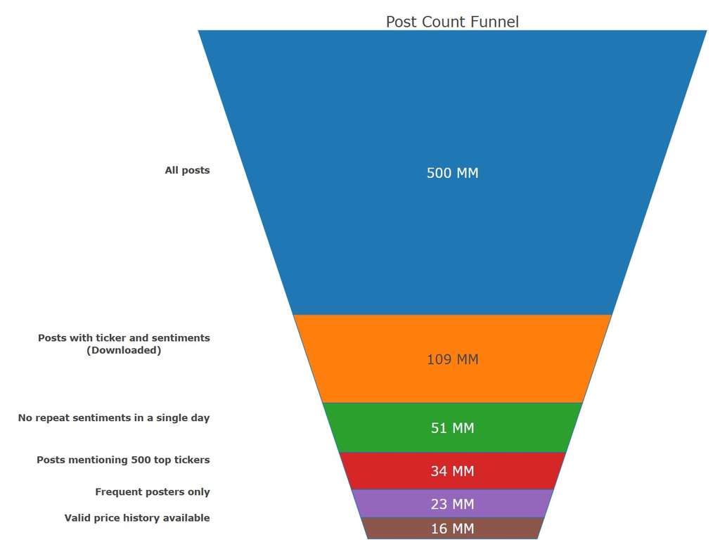

## Managing The Data

- The R dplyr package is great a manipulating large data frames but is designed for in-memory usage.
- Manipulating very large data sets is best done with a database package that works with connections to those data sets, wherever they reside.
- We will use the super-fast **DuckDB** for R (Python users should consider Polars).

## Managing The Data (cont.)

- DuckDB has a dplyr frontend called **duckplyr** where most dplyr verbs are implemented.
- We’ll save and retrieve (connect to) files in **Parquet** format which, like duckDB, is column-oriented.
- **Differences in syntax are almost invisible but speed advantage is enormous.**

## duckDB Is SQL-based….

```r
# Find the largest sepals/petals in the Iris data set
library(duckdb)

con <- dbConnect(duckdb())
duckdb_register(con, "iris", iris)

query <- r'(
    SELECT count(*) AS num_observations,
    max("Sepal.Width") AS max_width,
    max("Petal.Length") AS max_petal_length
    FROM iris
    WHERE "Sepal.Length" > 5
    GROUP BY ALL
    )'

dbGetQuery(con, query)
```

## … But You Don’t Have To Learn SQL

```r
# Find the largest sepals/petals in the Iris data set using duckplyr
library("duckplyr")

iris |>
    filter(Sepal.Length > 5) |>
    summarize(.by = Species,
        num_observations = n(),
        max_width = max(Sepal.Width),
        max_petal_length = max(Petal.Length),
        na.rm = TRUE) |>
    collect()
```

## duckplyr Key Points

- Chains of multiple verbs are only evaluated when `collect()` or `as_tibble()` is called, even when the data remains on disk and not in memory.
- Not all verbs are implemented, but duckplyr automatically falls back to dplyr when needed.
- Have a strategy around when to “materialize” data.

## Downloading the Data is Easy!

- We are only interested in files containing the user ID, timestamp, symbol and sentiment columns.
- This 100-million-row subset is stored as 34 CSV files in an AWS S3 bucket.
- Fetching took about 25 seconds per file on my machine.
- Once downloaded, we can treat the entire dataset on disk as a single data frame.

## Downloading the Data is Easy (code)

```r
library(tidyverse)
library(duckplyr)

db_exec("INSTALL httpfs;")
db_exec("LOAD httpfs;")
db_exec("SET s3_region='us-west-2';")

base_url <- "https://stocktwits-nyu.s3.amazonaws.com/dataset/v1/data/csv/"
dataset <- "symbol_sentiments"
file_nums <- sprintf("%02d", 0:33)
S3_file_list <- paste0(base_url, dataset, "/",dataset, "_", file_nums, ".csv")
local_file_list <- paste0("data/", dataset, "_", file_nums, ".parquet")

for (n in 1:length(S3_file_list)) {
  df <- read_csv_duckdb(S3_file_list[n]) |>
    compute_parquet(local_file_list[n]) }

# ALL SET! Read all parquet files and off you go - instantly!
sentiments <- read_parquet_duckdb(local_file_list)
```

## Understand what materialization means

```r
# This gets the answer almost instantly.
sentiments |> summarise(total_rows = n())
# A duckplyr data frame: 1 variable
#         n
#     <int>
#1 106105966

# This is bad
sentiments |> nrow()
# Error:
# ! Materialization would result in more than 250000 rows.
# Use `collect()` or `as_tibble()` to materialize.
```

## No More Code Today. Just *RESULTS!*

- Refer to my GitHub repository for all the analytic code and details.
- https://github.com/apsteinmetz/stocktwits

## The Cleaned Data

Sample StockTwits Posts After Cleaning and Filtering

| user_id | ticker | date | bullish |
| --- | --- | --- | --- |
| 3593665 | XPEV | 2020-11-19 | TRUE |
| 1678424 | F | 2022-01-21 | TRUE |
| 3254854 | SPY | 2021-12-20 | TRUE |
| 32114 | USO | 2017-05-09 | TRUE |
| 1540938 | ENDPQ | 2022-08-11 | TRUE |
| 1210343 | ACRX | 2018-07-30 | TRUE |
| 3625032 | NNDM | 2021-02-03 | TRUE |
| 678548 | TSLA | 2017-03-03 | FALSE |
| 1885910 | CENN | 2021-04-26 | TRUE |
| 2846728 | TWTR | 2021-03-30 | FALSE |

## What are the most popular Tickers?

No surprise, megacaps, meme stocks, and SPY.

Most Popular StockTwits Tickers

| ticker | count | start_date | end_date |
| --- | --- | --- | --- |
| AMC | 1,630,346 | 2013-12-17 | 2022-12-31 |
| SPY | 1,458,864 | 2010-06-02 | 2022-12-31 |
| TSLA | 1,036,455 | 2010-09-16 | 2022-12-31 |
| AAPL | 654,935 | 2010-06-03 | 2022-12-31 |
| AMD | 472,878 | 2010-09-04 | 2022-12-31 |
| GME | 439,350 | 2010-08-21 | 2022-12-31 |
| NIO | 438,048 | 2012-12-20 | 2022-12-31 |
| OCGN | 420,353 | 2014-12-15 | 2022-12-31 |
| AMZN | 357,618 | 2010-06-02 | 2022-12-31 |
| META | 323,491 | 2011-01-09 | 2022-12-31 |

## Zipf’s Law - Stocktwits Like to Pile On

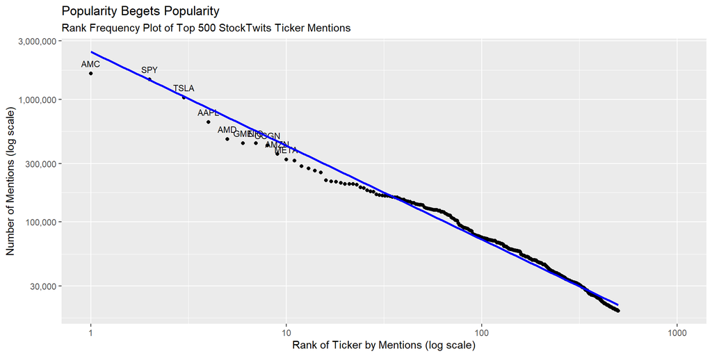

## Get Prices For Most Popular Tickers

- We the `yahoofinancer` package to download historical OHLC prices from Yahoo Finance.
- Other download packages are available, e.g. `quantmod`, `tidyquant`, `yfR`.
- Some tickers don’t have valid prices histories aligned with our sentiment data. We’ll ignore them.

## Build Track Records

- Map each post to the adjusted close price on the post date and the price 7 days later.
- Test whether the return and return vs. SPY align with sentiment.

Sample Track Records

| user_id | ticker | date | bullish | win_absolute | win_vs_SPY |
| --- | --- | --- | --- | --- | --- |
| 3593665 | XPEV | 2020-11-19 | TRUE | TRUE | TRUE |
| 1678424 | F | 2022-01-21 | TRUE | FALSE | FALSE |
| 3254854 | SPY | 2021-12-20 | TRUE | TRUE | TRUE |
| 32114 | USO | 2017-05-09 | TRUE | TRUE | TRUE |
| 3625032 | NNDM | 2021-02-03 | TRUE | TRUE | FALSE |

## Calculate Batting Averages

Sample Batting Averages

| user_id | total | wins | win_rate |
| --- | --- | --- | --- |
| 3055342 | 51 | 24 | 47% |
| 3354926 | 181 | 81 | 45% |
| 260786 | 100 | 32 | 32% |
| 2964764 | 123 | 53 | 43% |
| 3157678 | 73 | 29 | 40% |

## Stocktwits Are Usually Wrong

- Of 68,183 posters with track records, 37,767 had statistically significant batting averages at the 5% level (p < 0.05).
- Of those, the alpha direction was negative for 83%.

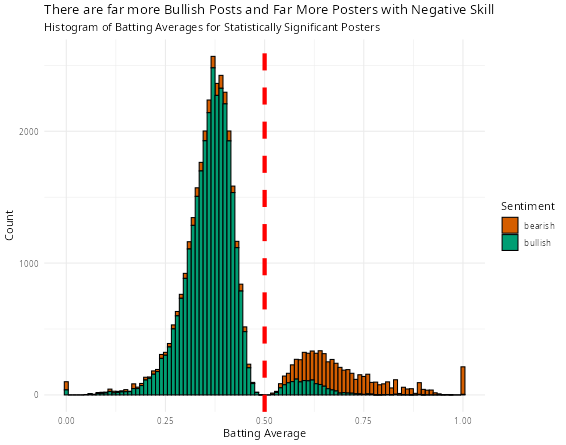

## Develop Trading Strategy

- Divide posts into 3 month samples.
- Test for significant posters in the window.
- During the 1 month following out of sample, follow sentiment from positive alpha poster, and do the opposite from a negative alpha poster.
- Reverse the trade 7 days later.
- Deploy uninvested cash in SPY ETF.

## This Generates a LOT of trades

Feasible for a quant shop, not us.

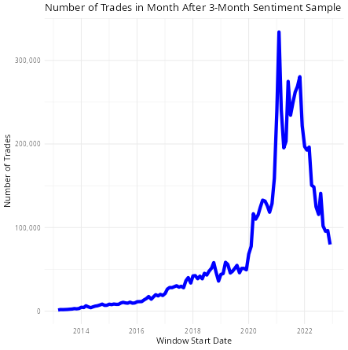

## Too Bad. The Gains Look Impressive

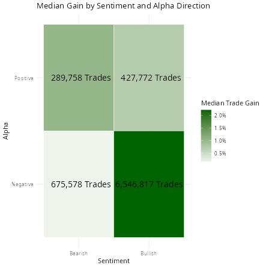

## Develop Realistic Strategy for the Small Investor

- Limit trade volume to first 100 signals per month.
- Equal weight each trade.
- Long only. Note that includes buys where negative alpha posters say “Sell.”

## Results!

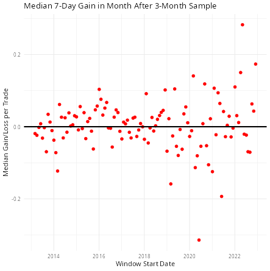

## Should I Quit My Day Job?

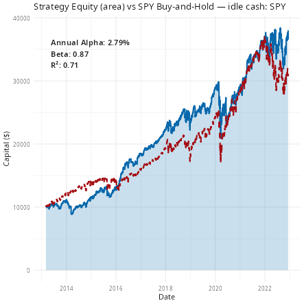

## Caveats

- Transaction costs ignored.
- Execution Slippage ignored.
- Yahoo Finance data quality issues.
- We use a 7-day window but who knows what the poster’s horizon is?
- I used AI “vibe coding” to build the trade simulator. It might be crap.

## Thank You!

Visit My Data Science Blog:

- `outsiderdata.net`

This Deck Was Built With Quarto by Posit. Source Here:

- `https://github.com/apsteinmetz/r_meetup_talk_2`

Connect With Me:

- `@adababbage`
- `artsteinmetz.com`
- `asteinmetz`

## Bibliography

Li, Xingji, Nasser Al Ansari, and Aaron Kaufman. 2025. “StockTwits: Comprehensive Records of a Financial Social Media Platform from 2008 to 2022.” *Journal of Quantitative Description: Digital Media* 5. https://doi.org/10.51685/jqd.2025.020.